# **52002 Final Assignment Spring 2021**

## **Instructions**

Please **read carefuly the instructions**:

You should upload to moodle by August 23rd 23:59 *two* files:

1. A single `ipynb` file called `<ID>.ipynb` (where `<ID>` is replaced by your `ID` number) filled with your code, text and results, **AFTER** all the commands were run such that we see in the output blocks the results.
2. An single `html` file called `<ID>.html` with the complied code including *all output*. Please verify before submitting that you have all the intended output in your generated html.  
   **Note:** Google colab doesn't support conversion to html. Please download your filled `ipynb` notebook and then convert it to html using Jupyter notebook. See instructions [here](https://stackoverflow.com/questions/53460051/convert-ipynb-notebook-to-html-in-google-colab).

**Note:** The assignment is **individual**. You may talk to your friends about general topics related to the course, and technical issues (e.g problems connecting to a database). But you should think about the problems and implement your solutions **individually**. If you're not sure, ask the instructors.

**How to write your answers:** In addition the code blocks that you should fill in the designated places, you should explain in text blocks your analysis steps and and results before/after the code blocks. Code blocks without any explanations may result in a reduction in grade even if they are correct.

**Grading:** The assignment contains four parts, each divided into a few sub-questions. The number of points for each sub-question is listed next to it. The total number of points is $105$. However, the maximal grade for the final assignment is $100$.

**Note:** Points from your grade will be deducted for submitting wrong/missing parts of files OR if not submitting the complete generated/complied output.

**Note:** Some parts of the code may take a few minutes to run.

Be patient. However, don't leave everything to run at the last minute but prepare in advance so your entire notebook runs and finishes on time.

If a certain part runs over half an hour this means you're doing something wrong, or that there are connections/other problems with the google colab server.

### **Libraries and Other Requirements**

Please run the following two cells as is without modifications.

1. The first contains `pip` install commands to install required python modules. Some errors are expected, they are mainly caused by inconsistent versions.
2. The second contains python code for importing modules and specific classes from them that can be used later in the code.
- `boto3` is the AWS python official module
- `flair` is a natural language processing (NLP) library
- `nltk` is another natural language toolkit library
- `sklearn` is a popular python machine learning library

You are allowed to include additional modules and commands as you wish. It it is your responsibility to install them, call them appropriately, and describe them if you do.

```python
# Installing libraries
%pip install boto3
!pip3 install flair
```

```python
# Importing the AWS module. Allows also to work with and read from zipped files.
import boto3
import numpy as np
import pandas as pd
import gzip
import time

# Useful text-preprocessing commands
from flair.models import TextClassifier
from flair.data import Sentence
classifier = TextClassifier.load('sentiment-fast') # building sentiment features

import nltk
from nltk.corpus import stopwords
from nltk.stem import WordNetLemmatizer
from nltk.tokenize import word_tokenize
nltk.download('punkt')
nltk.download('stopwords')
nltk.download('wordnet')

# Useful machine-learning commands
from sklearn.feature_extraction.text import TfidfVectorizer
from sklearn.model_selection import train_test_split
from sklearn import preprocessing
from sklearn.linear_model import LogisticRegression,SGDClassifier
from sklearn import metrics
from sklearn_pandas import DataFrameMapper

import matplotlib.pyplot as plt  # for plotting

# tic and toc functions for measuring time
def tic():
    import time
    global startTime_for_tictoc
    startTime_for_tictoc = time.time()

def toc(pName=''):
    import time
    if 'startTime_for_tictoc' in globals():
        delta = time.time() - startTime_for_tictoc
        print("{}: Elapsed time is ".format(pName) + str(int(delta)) + " seconds, or " + str(round(delta/60,2))+ " minutes")
    else:
        delta = -1
        print("Toc: start time not set")
    return delta
```

```
2021-08-07 01:24:50,721 loading file /root/.flair/models/sentiment-en-mix-ft-rnn.pt
```

## **A general description of the assignment**

In this assignment, we will read and analyze a large dataset from the Amazon Web Service (AWS) Simple Storage Service (S3).  
The data we will work with is the *Amazon Customer Reviews Dataset*, that contains textual data of customer reviews, in addition to the rating of each product (on a scale of $1$ to $5$) and additional features.

The four parts of the assignments are:

- **Part 1:** Connecting to the service and reading data
- **Part 2:** Data preprocessing and feature engineering
- **Part 3:** Fitting a classification model to a large dataset
- **Part 4:** Fitting streaming data using Stochastic Gradient Descent

#### **About the Data: Amazon Customer Reviews Dataset**

The dataset contains over $130$ million customer reviews vailable to researchers as part of this release, collected from from 1995 until 2015. The data is available in tab-delimited compressed (zipped) `tsv` files in the `amazon-reviews-pds` S3 `bucket` (see later).  
Each line in the data files corresponds to an individual review (tab delimited).

Bucket: `amazon-reviews-pds`  
Tab Separated Values Data pre-fix: `tsv`

The dataset is divided into different product categories, identified by `keys`. For example, a category for `cameras` is represented by the key:  
`amazon-reviews-pds/tsv/amazon_reviews_us_Camera_v1_00.tsv.gz`

You can find more information about the dataset [here](https://s3.amazonaws.com/amazon-reviews-pds/readme.html).

#### **What is Amazon Web Services S3?**

Amazon Simple Storage Service (Amazon S3, similar to Google Cloud Storage, Azure Blob Storage, ...) is storage for the Internet. It is designed to make web-scale data transfer, reading, writing and computing easier. Amazon S3 provides a simple interface that gives any developer access to the same highly scalable, reliable, fast, and inexpensive data storage infrastructure using code (for example in `python`).  
However, the S3 file system is not typical, and is built around a key-value/object mapping (key is the location, object is the content and meta data of the file).

These key-values are stored in "folders" called `buckets`. Buckets are the fundamental containers in Amazon S3 for data storage, and contain `objects` (files). We can store an unlimited amount of data in a bucket, where each object can contain up to 5 TB of data. Each object is stored and retrieved using a unique developer-assigned key.

**Objects:**

Objects are the fundamental entities stored in Amazon S3. Objects consist of object data and metadata. The data portion is opaque to Amazon S3. The metadata is a set of `name-value` pairs that describe the object. They include some default metadata, such as the date last modified and standard HTTP metadata, such as Content-Type, and also custom metadata specified at the time the object is stored.

**Keys:** An `object` is uniquely identified within a `bucket` by a `key` (name) and a `version ID`. Every `object` has exactly one `key`.  
That is, thee combination of a (`bucket`, `key`, `version ID`) uniquely identifies each `object` (the version ID is optional).

We will use commands for downloading or reading lines from an `object` using the `key`.

For more information see [here](https://docs.aws.amazon.com/AmazonS3/latest/userguide/Welcome.html).

### **Part 1: Connecting to Amazon Web Server and reading data using boto3**

In this section we will get familiar with the AWS S3 cloud storage using API modules. We will create a connection to the cloud storage and access the data.  
Specifically, we will use the popular `boto3` AWS library for python to connect to the `amazon-reviews-pds` bucket.

**1.(a) [3 pt]** Using `boto3`'s method called `resource`, run the code below create a connection to AWS S3 named `s3conn`, with your `aws_access_key_id` and `aws_secret_access_key`.

Add a line defining a variable called `reviews` that points the `s3conn` conncetion to Amazon's `amazon-reviews-pds` data using the `Bucket` method of `boto3`. Print the `reviews` variable to verify that it represents the `Bucket` with the `amazon-reviews-pds` dataset.

**Solution:**

```python
# If you have an AWS account, replace these with your key-id and access key:
akid = 'AKIAUYOPAAPXSSENNKIV'
sak = 'Br4Y2W239IIsBMWlFSro3/ce19eqtU2ONseMTN1c'

# Using boto3's resource method, create a connection to AWS S3
s3conn = boto3.resource(
    's3',
    aws_access_key_id = akid,
    aws_secret_access_key = sak
)

# Add your code here
reviews = s3conn.Bucket('amazon-reviews-pds')
print(reviews)
```

```
s3.Bucket(name='amazon-reviews-pds')
```

**1.(b) [6 pt]** We are only interested in the data within the `tsv` (tab separated values) parent-key ("folder"):

- Run the code-cell below to get all the `keys` of the files within the `tsv` parent-key and their respected file size into a dedicated list.  
  Each key should contain the name of the `object` and the size of the `object` in bytes.
- Filter the keys to include only `tsv` objects containing reviews, and only from the `us`.
- Print the first $15$ elements of the filtered keys list. In addition, print the total size in GB (rounded to 3 dec. place) of all the objects of type `tsv` (zipped).

**Solution:**

```python
keys_list = []
for my_bucket_object in reviews.objects.all():
    keys_list.append([my_bucket_object.key,my_bucket_object.size])

keys_list
# Filter only files from within the tsv parent folder
keys_list = [elem for elem in keys_list if 'tsv/' in elem[0]]
keys_list.pop(0) # removing "['tsv/', 0]" that deosn't stant for a file within the folder
keys_list = [elem for elem in keys_list if 'multilingual' not in elem[0]]
# Print the first 15 elements
[print(keys_list[j]) for j in range(15)]
print('-'*80)
# Total Size
sum = 0
for elem in keys_list:
  sum += elem[1]
print('The total size (in GB) of all the files in tsv folder is '+ str(np.round(sum/1000000000,3))+ '.')
```

```
['tsv/amazon_reviews_us_Apparel_v1_00.tsv.gz', 648641286]
['tsv/amazon_reviews_us_Automotive_v1_00.tsv.gz', 582145299]
['tsv/amazon_reviews_us_Baby_v1_00.tsv.gz', 357392893]
['tsv/amazon_reviews_us_Beauty_v1_00.tsv.gz', 914070021]
['tsv/amazon_reviews_us_Books_v1_00.tsv.gz', 2740337188]
['tsv/amazon_reviews_us_Books_v1_01.tsv.gz', 2692708591]
['tsv/amazon_reviews_us_Books_v1_02.tsv.gz', 1329539135]
['tsv/amazon_reviews_us_Camera_v1_00.tsv.gz', 442653086]
['tsv/amazon_reviews_us_Digital_Ebook_Purchase_v1_00.tsv.gz', 2689739299]
['tsv/amazon_reviews_us_Digital_Ebook_Purchase_v1_01.tsv.gz', 1294879074]
['tsv/amazon_reviews_us_Digital_Music_Purchase_v1_00.tsv.gz', 253570168]
['tsv/amazon_reviews_us_Digital_Software_v1_00.tsv.gz', 18997559]
['tsv/amazon_reviews_us_Digital_Video_Download_v1_00.tsv.gz', 506979922]
['tsv/amazon_reviews_us_Digital_Video_Games_v1_00.tsv.gz', 27442648]
['tsv/amazon_reviews_us_Electronics_v1_00.tsv.gz', 698828243]
--------------------------------------------------------------------------------
The total size (in GB) of all the files in tsv folder is 32.377.
```

**1.(c) [6 pt]** Using the output of **1.(b)**, create a `pandas` dataframe named `file_categories_df` with the following columns:

- `category`: the file's (object's) category, parsed from the key string (without unnecessary characters). If there are multiple categories with the same name, use `_00, _01` ... suffixes for different versions
- `size`: the size in bytes of the file
- `sizeGB`: the size in GB of the file
- `estSizeGB`: the estimated size in GB of the `uncompressed` file, assuming the gzip compresses a file to size of around `30%` of the original size.

For example, one row of the table should be:  
`Digital_Software, 18997559, 0.017693, 0.05898`

Show the top-10 rows of the created data-frame using the `head` method.

**Solution:**

```python
def exctract_category(s):
  """
  Given s, a name of a file from the `tsv` parent folder, this function
  extracts the category it represents.
  It seems that all the names in our folder share a same same general
  pattern:
  - They start with "tsv/amazon_reviews_"
  - Then comes the catoory
  - Indicator for if there are similar files, given in v*_**. It is
    important to notice that all the files in our folder share the same
    version, v1. If we had other versions as well, we coulf have used
    the "re" package for locating the pattern (_v*) or iterate naively
    over different indecators: [v1,v2,...] (the second approach is
    obviously inferior).
  """

  def LocateFirstUpper(s):
    """
    Locate the first incident of upper case letter and return its location.
    In some cases the string starts with *_us_Category. Of course, it is
    a toy problem and in a real case we may face different courtries with
    different number of words. Since caterogy names start with an upper
    case letter, I start the string by looking for these incidents (rather
    than remove 'us_' directly, or split by '_').
    """
    for i in range(0, len(s)):
      if (s[i].istitle()):
        return i
  if "reviews" not in s:
    return "None"
  s1 = s.replace("tsv/amazon_reviews_", "")
  stop = s1.find("_v1")
  s1 = s1.replace("_v1", "")
  s1 = s1[:(stop+3)]
  if s1.startswith("multilingual"):
    return s1
  else:
    start = LocateFirstUpper(s1)
    s1 = s1[start:]
    return s1

# **As I understand it**, multilinguals and indices should not be included
# since they don't cover reviews.
keys_list = [elem for elem in keys_list if 'amazon_reviews' in elem[0]]

file_categories_df = pd.DataFrame()
for j in range(len(keys_list)):
  temp_df = pd.DataFrame([exctract_category(keys_list[j][0]), \
                keys_list[j][1], \
                keys_list[j][1]/1000000000,
                (keys_list[j][1]/1000000000)/0.3]
               ).T
  file_categories_df = pd.concat([file_categories_df, temp_df],
                                 axis = 0, ignore_index = True)
file_categories_df.columns = ['category', 'size', 'sizeGB', 'estSizeGB']
file_categories_df.head(10)
```

|  | category | size | sizeGB | estSizeGB |
| --- | --- | --- | --- | --- |
| 0 | Apparel_00 | 648641286 | 0.648641 | 2.16214 |
| 1 | Automotive_00 | 582145299 | 0.582145 | 1.94048 |
| 2 | Baby_00 | 357392893 | 0.357393 | 1.19131 |
| 3 | Beauty_00 | 914070021 | 0.91407 | 3.0469 |
| 4 | Books_00 | 2740337188 | 2.74034 | 9.13446 |
| 5 | Books_01 | 2692708591 | 2.69271 | 8.9757 |
| 6 | Books_02 | 1329539135 | 1.32954 | 4.4318 |
| 7 | Camera_00 | 442653086 | 0.442653 | 1.47551 |
| 8 | Digital_Ebook_Purchase_00 | 2689739299 | 2.68974 | 8.9658 |
| 9 | Digital_Ebook_Purchase_01 | 1294879074 | 1.29488 | 4.31626 |

**1.(d) [6 pt]** **Reading the Data:**

- Run the code cell below using the `download_file` method for the `bucket` of `s3conn`, to download the file of one of the six *smallest* categories (size < `30MB`) into the colab/local file-system, and read the entire file into a dataframe.
- Read the entire data from the category into a pandas dataframe called `df` and print the number of rows (data points) and columns (features).
- Compute and print the average size in bytes of each data point (an amazon product review). Use this number and the total size computed in **1.(b)** to estimate the total number of reviews in the entire dataset over all categories. How close is it to $130$ million? explain what can cause the difference in numbers.
- Apply `df.head(5)` to view the start of the data-frame.

**Note:** during code development, it is allowed here and in other sub-questions (and even recommended) to limit the size of what we load into memory. However, for submission, the full files/requested data sizes should be used.

**Solution:**

```python
# Identify the smalles six categories
file_categories_df.sort_values(['estSizeGB']).\
  head(6)

# It seems that Digital_Video_Games falls in the 6 smallest categories.
```

[output not shown]

```python
print('file to read/stream: ', keys_list[13][0]) # downloading: Digital_Video_Games. Modify to download a different category
fileToStream = keys_list[13][0]
# Reading the file (may take time?)
s3conn.Bucket('amazon-reviews-pds').download_file(fileToStream, 'tmp.gz')
% ls /content/ -lah

with gzip.open('/content/tmp.gz', 'rb') as f_in:
    tmp = f_in.readlines() # Reading lines into a python object

# Turn tmp into a DataFrame named `df`
def BytesToStr(b):
  lst = b.split(b'\t')
  return [elem.decode('UTF-8') for elem in lst]

df = pd.DataFrame(list(map(BytesToStr, tmp)))
df.columns = list(df.iloc[0])
df = df.iloc[1:].reset_index(drop = True)

# Read the entire data from the category into a pandas dataframe called df and
# print the number of rows (data points) and columns (features).
print("-"*80)
print('df contains {r} rows (data points) and {c} columns (features).'.\
      format(r=df.shape[0], c=df.shape[1]))
print("-"*80)
```

```
file to read/stream:  tsv/amazon_reviews_us_Digital_Video_Games_v1_00.tsv.gz
total 27M
drwxr-xr-x 1 root root 4.0K Aug  7 01:25 ./
drwxr-xr-x 1 root root 4.0K Aug  6 17:43 ../
drwxr-xr-x 4 root root 4.0K Jul 16 13:19 .config/
drwxr-xr-x 1 root root 4.0K Jul 16 13:20 sample_data/
-rw-r--r-- 1 root root  27M Aug  7 01:25 tmp.gz
--------------------------------------------------------------------------------
df contains 145431 rows (data points) and 15 columns (features).
--------------------------------------------------------------------------------
```

```python
# Calculate bytes for each row
def BytesCalc(ser):
  size = 0
  for l in range(len(ser)):
    size += len(ser[l]) # 1 bytes per char
  return size

AVGWeight = np.round(np.mean(df.apply(BytesCalc, axis=1)),3)

print("-"*80)
print(f"The average weight per review (row) is {AVGWeight} Bytes.")
print("-"*80)
```

```
--------------------------------------------------------------------------------
The average weight per review (row) is 488.938 Bytes.
--------------------------------------------------------------------------------
```

Compute and print the average size in bytes of each data point (an amazon product review). Use this number and the total size computed in 1.(b) to estimate the total number of reviews in the entire dataset over all categories. How close is it to 130 million? explain what can cause the difference in numbers.

In **1.(b)** I found that the total size of all the categories together is 32.377 GBs. Based on our sample of reviews of digital video games, I have found that the average size of a review is about 489 bytes. So, based on this information, the total number of reviews should be around 66,219,029.

Apply df.head(5) to view the start of the data-frame.

```python
print("Present the first 5 observations of the data:")
df.head(5)
```

```
Present the first 5 observations of the data:
```

|  | marketplace | customer_id | review_id | product_id | product_parent | product_title | product_category | star_rating | helpful_votes | total_votes | vine | verified_purchase | review_headline | review_body | review_date\n |
| --- | --- | --- | --- | --- | --- | --- | --- | --- | --- | --- | --- | --- | --- | --- | --- |
| 0 | US | 21269168 | RSH1OZ87OYK92 | B013PURRZW | 603406193 | Madden NFL 16 - Xbox One Digital Code | Digital_Video_Games | 2 | 2 | 3 | N | N | A slight improvement from last year. | I keep buying madden every year hoping they ge... | 2015-08-31\n |
| 1 | US | 133437 | R1WFOQ3N9BO65I | B00F4CEHNK | 341969535 | Xbox Live Gift Card | Digital_Video_Games | 5 | 0 | 0 | N | Y | Five Stars | Awesome | 2015-08-31\n |
| 2 | US | 45765011 | R3YOOS71KM5M9 | B00DNHLFQA | 951665344 | Command & Conquer The Ultimate Collection [Ins... | Digital_Video_Games | 5 | 0 | 0 | N | Y | Hail to the great Yuri! | If you are prepping for the end of the world t... | 2015-08-31\n |
| 3 | US | 113118 | R3R14UATT3OUFU | B004RMK5QG | 395682204 | Playstation Plus Subscription | Digital_Video_Games | 5 | 0 | 0 | N | Y | Five Stars | Perfect | 2015-08-31\n |
| 4 | US | 22151364 | RV2W9SGDNQA2C | B00G9BNLQE | 640460561 | Saints Row IV - Enter The Dominatrix [Online G... | Digital_Video_Games | 5 | 0 | 0 | N | Y | Five Stars | Awesome! | 2015-08-31\n |

### **Part 2: Data preprocessing and feature engineering**

In this part we use the textual data to create predictive features, and preprocess additional features, to prepare the data-frame to be used in training a classifier.

**2.(a) [7 pt]** Apply the following common text normalization and standardization steps to the `review_body` textual column. It is recommended to use the `nltk` package:

1. Create a new column named `reviews_processed`, and assign it the `review_body` strings, just with all characteres as lower-case letters. All the following transformations should be done on the `reviews_processed` column.
2. Split to words using the `word_tokenize` method.
3. Keep only alpha-numerical values (you can use `str.isalpha()`).
4. Unite together words with similar meanining using the `WordNetLemmatizer` command.
5. Remove non-informative words (stop-words) using the `stopwords` command
6. Finally, join back all the tokens (words) to a single string for each row.
7. Remove rows with empty strings of `review_body`.

Write first a function that recieves as input a data-frame and modifies it according to the steps below. Then, apply the function to the `df` dataframe.

Show the top-10 records using the command `df.reviews_processed.head(10)` once you are done.

**Note:** Running the commands for this sub-questions may take a few minutes.

```python
def function_2a(df):
  # 1. Create a new column
  df['reviews_processed'] = df['review_body'].str.lower()

  # 2. Split to words
  from nltk.tokenize import TweetTokenizer
  tknzr = TweetTokenizer()
  df['reviews_processed'] = [tknzr.tokenize(elem) for elem in df['reviews_processed']]

  # 3. Alphanumeric
  def alpha(s):
    return [elem for elem in s if elem.isalpha() is True]
  df['reviews_processed'] = [alpha(elem) for elem in df['reviews_processed']]

  # 4. Unite together words
  def lemma(s):
    from nltk.stem import WordNetLemmatizer
    # Init the Wordnet Lemmatizer
    lemmatizer = WordNetLemmatizer()
    return [lemmatizer.lemmatize(elem) for elem in s]
  df['reviews_processed'] = [lemma(elem) for elem in df['reviews_processed']]

  # 5. Remove non-informative words (stop-words)
  from nltk.corpus import stopwords
  def stpwds(s):
    stop_words = set(stopwords.words('english'))
    return [elem for elem in s if not elem in stop_words]
  df['reviews_processed'] = [stpwds(elem) for elem in df['reviews_processed']]

  # 6. join back all the tokens (words) to a single string
  df['reviews_processed'] = [" ".join(elem) for elem in df['reviews_processed']]

  # 7. Remove rows with empty strings of review_body
  df = df[df['review_body']!=""]
  df = df[df['reviews_processed']!=""] # I ADDED THIS, WAIT FOR LI'S RESPONSE
  df.reset_index(drop = True, inplace = True)

  return df

df = function_2a(df)
df.reviews_processed.head(10)
```

```
0    keep buying madden every year hoping get back ...
1                                              awesome
2    prepping end world one thing installed pc hail...
3                                              perfect
4                                              awesome
5                                              awesome
6    like new skill like herbalism camping fun also...
7                                                super
8                                excellent fast secure
9                                                   ok
Name: reviews_processed, dtype: object
```

**2.(b) [6 pt]** **Sentiment analysis using the `flair` library:** We next want to add *sentiment* features to each review, that use a pre-trained model to predict if the review text is positive or negative. Note that we use this only as a way for defining new predictive features from the text. We will train our actual classifier in **Part 3**.

1. *Execute* the cells below with the command:  
   `classifier = TextClassifier.load('sentiment-fast')`  
   to load the a pre-trained text classifier object
2. Next, Loop over the first $10$ reviews and for each one apply `flair`'s `Sentence` method on the processed review text, an input the resulting sentence to the `classifier.predict()` method. Print for the first $10$ reviews out both the reviews and their sentiment (`NEGATIVE/POSITIVE` and the sentiment score). Do the generated sentiments represent the text?
3. How long does it take to compute the sentiments of `100, 1,000`, and `10,000` datapoints in this manner? (do not print them, but make sure that the sentiments are actually computed). Extrapolate and estimate how long would it take to compute the sentiments over all data points in your category.

**Solution:**

```python
# 1. Execute the cells below
classifier = TextClassifier.load('sentiment-fast')

# 2. Loop over the first  10  reviews
from flair.data import Sentence
for j in range(10):
  sent = df['reviews_processed'][j]
  sentence = Sentence(sent)
  classifier.predict(sentence)

  print('-'*80)
  print(f'Review No.{j}:')
  print(df['review_body'][j])
  print(' - -'*15)
  print(f'[Sentiment, Sentiment Score]:')
  print(sentence.labels)
```

```
2021-08-07 01:26:53,364 loading file /root/.flair/models/sentiment-en-mix-ft-rnn.pt
--------------------------------------------------------------------------------
Review No.0:
I keep buying madden every year hoping they get back to football. This years version is a little better than last years -- but that's not saying much.The game looks great. The only thing wrong with the animation, is the way the players are always tripping on each other.<br /><br />The gameplay is st…
 - - - - - - - - - - - - - - - - - - - - - - - - - - - - - -
[Sentiment, Sentiment Score]:
[NEGATIVE (0.9999)]
--------------------------------------------------------------------------------
Review No.1:
Awesome
 - - - - - - - - - - - - - - - - - - - - - - - - - - - - - -
[Sentiment, Sentiment Score]:
[POSITIVE (0.9971)]
--------------------------------------------------------------------------------
Review No.2:
If you are prepping for the end of the world this is one of those things that you should have installed on your-end-of-the-world-proof PC.  Hail to the great Yuri!
 - - - - - - - - - - - - - - - - - - - - - - - - - - - - - -
[Sentiment, Sentiment Score]:
[POSITIVE (0.8517)]
--------------------------------------------------------------------------------
Review No.3:
Perfect
 - - - - - - - - - - - - - - - - - - - - - - - - - - - - - -
[Sentiment, Sentiment Score]:
[POSITIVE (0.9941)]
--------------------------------------------------------------------------------
Review No.4:
Awesome!
 - - - - - - - - - - - - - - - - - - - - - - - - - - - - - -
[Sentiment, Sentiment Score]:
[POSITIVE (0.9971)]
--------------------------------------------------------------------------------
Review No.5:
Awesome!
 - - - - - - - - - - - - - - - - - - - - - - - - - - - - - -
[Sentiment, Sentiment Score]:
[POSITIVE (0.9971)]
--------------------------------------------------------------------------------
Review No.6:
i like the new skills like herbalism in this, and camping is fun. i also like all the new build mode items
 - - - - - - - - - - - - - - - - - - - - - - - - - - - - - -
[Sentiment, Sentiment Score]:
[POSITIVE (0.8617)]
--------------------------------------------------------------------------------
Review No.7:
Super
 - - - - - - - - - - - - - - - - - - - - - - - - - - - - - -
[Sentiment, Sentiment Score]:
[POSITIVE (0.9509)]
--------------------------------------------------------------------------------
Review No.8:
Excellent, fast and secure!!!
 - - - - - - - - - - - - - - - - - - - - - - - - - - - - - -
[Sentiment, Sentiment Score]:
[POSITIVE (0.9975)]
--------------------------------------------------------------------------------
Review No.9:
Ok
 - - - - - - - - - - - - - - - - - - - - - - - - - - - - - -
[Sentiment, Sentiment Score]:
[POSITIVE (0.564)]
```

Do the generated sentiments represent the text?

Overall it seems that using `flair` I was able to classify the processed sentences quite well. For simple examples such as in 1,3, and 4, both the prediction and the score align with the actual sentiment. Example 2 presents a more complex case, in which the extent of "positiveness" comes in an indirect manner (say, the writer did not use the words "awesome" or "great"). Nevertheless, the pre-trained classifier has succeeded in classifying it.

Similarly, in example 0, the negative review was said indirectly ("This years version is a little better than last years -- but that's not saying much."), but it seems that the classifier has correctly classified it into the negative class.  
Overall, impressive results!

```python
# 3. Calculate the time it taked to compute 100, 1000 and 10000 examples
tick100 = time.time()
for j in range(100):
  sent = df['reviews_processed'][j]
  sentence = Sentence(sent)
  classifier.predict(sentence)
tock100 = time.time()

tick1000 = time.time()
for j in range(1000):
  sent = df['reviews_processed'][j]
  sentence = Sentence(sent)
  classifier.predict(sentence)
  # print('-'*40)
  # print(j)
  # print(sent)
tock1000 = time.time()

tick10000 = time.time()
for j in range(10000):
  sent = df['reviews_processed'][j]
  sentence = Sentence(sent)
  classifier.predict(sentence)
tock10000 = time.time()

print(f'Time to calculate 100 examples: {tock100 - tick100}.')
print(f'Time to calculate 1000 examples: {tock1000 - tick1000}.')
print(f'Time to calculate 10000 examples: {tock10000 - tick10000}.')
```

```
Time to calculate 100 examples: 0.42114758491516113.
Time to calculate 1000 examples: 4.030073404312134.
Time to calculate 10000 examples: 41.62220287322998.
```

Extrapolate and estimate how long would it take to compute the sentiments over all data points in your category.

Roughly, it seems that prediction action takes a linear time. For the first 100 examples, it took 0.4 seconds. It took ~10 times longer to classify 10 times more words and ~100 for 100 times more words.  
Given that we have 145,429 rows classify them would take around 580 seconds.

**2.(c) [6 pt]** To speed up the sentiment retrieval, we would like to implement a `mini-batch` approach: We first create a list of sentences `Sentence(text)`s for all input texts, and then go over them in groups of size `mini_batch_size`, and apply the `.predict` function to the entire `mini-batch` instead of $1$ data-point at a time:

1. Define a `batch` function that has an iterable and a `mini-batch` size `int` as inputs, and yields out the mini-batches of the iterable.
2. Define a `get_sentiment` function that takes an `np.array` of text datapoints as input, and outputs a `np.array` of the label objects from the sentiments. Make sure you use the `mini_batch_size=128` and `verbose=True` parameters within the `.predict` method. Also, make sure you call the `.predict` method only once, on a list of `Sentence` objects.
3. Run the above functions on all the processed text datapoints of `df` using a `mini_batch_size` of `128`, and a `batch size` of `10,000`. Print out the total time it takes and compare it to the predicted time from **2.(b)**.
4. Add both the sentiments' scores (`sent_score`) and the sentiments' values (`sent_value`) as new separate colomns (new features) in `df`.

Execute a `df.head()` command to view the top values when done.

**Note:** Running the functions on all data points may take a few minutes.

**Solution:**

```python
# 1. Define a batch function

def batch(iterable, batch_size = 128):
  """
  Split an iterable object into batchas of size `batch_size`.
  Inputs:
  - `iterable`: an iterable object, list or np array. For pd DataFrame,
    this function can be used in order to return the indices in each
    mini batch.
  - `batch_size`: the size of each batch the function will return.
  Output:
  - `min_matches`: a list (of numbers/arrays/DataFrames), with each
    element in size `batch_size`.
  """
  # init
  min_matches = []
  idx = 0

  while idx + batch_size < len(iterable):
    # define and save a batch
    batch = iterable[idx:(idx + batch_size)]
    min_matches.append(batch)
    # update index
    idx += batch_size

  if idx + batch_size >= len(iterable):
    batch = iterable[idx:len(iterable)]
    min_matches.append(batch)

  return min_matches

# 2. define get_sentiment
def get_sentiment(iterable, mini_batch_size = 128, verbose=True):
  sentence = [Sentence(elem) for elem in iterable]
  classifier.predict(sentence,mini_batch_size = mini_batch_size, verbose=verbose)
  return np.array([elem.labels for elem in sentence])

# 3. Run the above functions on all the processed text datapoints
processed_text = df['reviews_processed'].values
# split our array into batches of size 10,000
processed_text_batches = batch(processed_text, batch_size = 10000)
# get sentiment for each batch (and compute time)
tic = time.time()
for i, batch in enumerate(processed_text_batches):
  print('-'*80)
  print(f'Started batch {i} (out of 15)..')
  print('-'*80)
  get_sentiment(batch, mini_batch_size = 128, verbose=True)
toc = time.time()

print('')
print('-'*80)
print(f'It took {toc-tic} seconds to compute sentiments for all of our examples.')
print('-'*80)
```

```
--------------------------------------------------------------------------------
Started batch 0 (out of 15)..
--------------------------------------------------------------------------------
```

```
--------------------------------------------------------------------------------
Started batch 1 (out of 15)..
--------------------------------------------------------------------------------
```

```
--------------------------------------------------------------------------------
Started batch 2 (out of 15)..
--------------------------------------------------------------------------------
```

```
--------------------------------------------------------------------------------
Started batch 3 (out of 15)..
--------------------------------------------------------------------------------
```

```
--------------------------------------------------------------------------------
Started batch 4 (out of 15)..
--------------------------------------------------------------------------------
```

```
--------------------------------------------------------------------------------
Started batch 5 (out of 15)..
--------------------------------------------------------------------------------
```

```
--------------------------------------------------------------------------------
Started batch 6 (out of 15)..
--------------------------------------------------------------------------------
```

```
--------------------------------------------------------------------------------
Started batch 7 (out of 15)..
--------------------------------------------------------------------------------
```

```
--------------------------------------------------------------------------------
Started batch 8 (out of 15)..
--------------------------------------------------------------------------------
```

```
--------------------------------------------------------------------------------
Started batch 9 (out of 15)..
--------------------------------------------------------------------------------
```

```
--------------------------------------------------------------------------------
Started batch 10 (out of 15)..
--------------------------------------------------------------------------------
```

```
--------------------------------------------------------------------------------
Started batch 11 (out of 15)..
--------------------------------------------------------------------------------
```

```
--------------------------------------------------------------------------------
Started batch 12 (out of 15)..
--------------------------------------------------------------------------------
```

```
--------------------------------------------------------------------------------
Started batch 13 (out of 15)..
--------------------------------------------------------------------------------
```

```
--------------------------------------------------------------------------------
Started batch 14 (out of 15)..
--------------------------------------------------------------------------------
```

```
--------------------------------------------------------------------------------
It took 375.5372095108032 seconds to compute sentiments for all of our examples.
--------------------------------------------------------------------------------
```

Print out the total time it takes and compare it to the predicted time from **2.(b)**.

Compared to my first assessment, that it will take around 580 seconds; using the mini-batches method made it shorter. Eventually, it took only 376 seconds.

```python
# 4. Add both the sentiments' scores (sent_score) and the sentiments' values (sent_value) as new separate colomns (new features)

# Note: sorry for doing it in separate code chunks, I wanted to go
# through the subsections one by one.

def batch(iterable, batch_size = 128):
  """
  Split an iterable object into batchas of size `batch_size`.
  Inputs:
  - `iterable`: an iterable object, list or np array. For pd DataFrame,
    this function can be used in order to return the indices in each
    mini batch.
  - `batch_size`: the size of each batch the function will return.
  Output:
  - `min_matches`: a list (of numbers/arrays/DataFrames), with each
    element in size `batch_size`.
  """
  # init
  min_matches = []
  idx = 0

  while idx + batch_size < len(iterable):
    # define and save a batch
    batch = iterable[idx:(idx + batch_size)]
    min_matches.append(batch)
    # update index
    idx += batch_size

  if idx + batch_size >= len(iterable):
    batch = iterable[idx:len(iterable)]
    min_matches.append(batch)

  return min_matches

processed_text = df['reviews_processed'].values
# split our array into batches of size 10,000
processed_text_batches = batch(processed_text, batch_size = 10000)
# get sentiment for each batch (and compute time)
results = np.array([])
for batch in processed_text_batches:
  results = np.append(results, get_sentiment(batch, mini_batch_size = 128, verbose=False))

# Add both the sentiments' scores (sent_score) and the sentiments' values (sent_value)
scores = []
values = []

for j in range(len(results)):
  result = results[j]
  scores.append(result.score)
  values.append(result.value)

df['sent_score'] = scores
df['sent_value'] = values
df.head()
```

|  | marketplace | customer_id | review_id | product_id | product_parent | product_title | product_category | star_rating | helpful_votes | total_votes | vine | verified_purchase | review_headline | review_body | review_date\n | reviews_processed | sent_score | sent_value |
| --- | --- | --- | --- | --- | --- | --- | --- | --- | --- | --- | --- | --- | --- | --- | --- | --- | --- | --- |
| 0 | US | 21269168 | RSH1OZ87OYK92 | B013PURRZW | 603406193 | Madden NFL 16 - Xbox One Digital Code | Digital_Video_Games | 2 | 2 | 3 | N | N | A slight improvement from last year. | I keep buying madden every year hoping they ge... | 2015-08-31\n | keep buying madden every year hoping get back ... | 0.999940 | NEGATIVE |
| 1 | US | 133437 | R1WFOQ3N9BO65I | B00F4CEHNK | 341969535 | Xbox Live Gift Card | Digital_Video_Games | 5 | 0 | 0 | N | Y | Five Stars | Awesome | 2015-08-31\n | awesome | 0.997095 | POSITIVE |
| 2 | US | 45765011 | R3YOOS71KM5M9 | B00DNHLFQA | 951665344 | Command & Conquer The Ultimate Collection [Ins... | Digital_Video_Games | 5 | 0 | 0 | N | Y | Hail to the great Yuri! | If you are prepping for the end of the world t... | 2015-08-31\n | prepping end world one thing installed pc hail... | 0.851653 | POSITIVE |
| 3 | US | 113118 | R3R14UATT3OUFU | B004RMK5QG | 395682204 | Playstation Plus Subscription | Digital_Video_Games | 5 | 0 | 0 | N | Y | Five Stars | Perfect | 2015-08-31\n | perfect | 0.994086 | POSITIVE |
| 4 | US | 22151364 | RV2W9SGDNQA2C | B00G9BNLQE | 640460561 | Saints Row IV - Enter The Dominatrix [Online G... | Digital_Video_Games | 5 | 0 | 0 | N | Y | Five Stars | Awesome! | 2015-08-31\n | awesome | 0.997095 | POSITIVE |

**2.(d) [8 pt] Setting binary variables:**

Write a function that modifies a `pandas` data-frame as follows:

- To simplify the target variable and get a binary classification problem, map star ratings of `1,2` to `0`, and `4,5` to `1` (corresponding to `negative` and `positive` sentiments respectively). Filter neutral star ratings of `3`.

In addition:

- Make sure the types of the data is compatible with modeling
- Set binary variables values to zero/one where applicable
- Get rid of `np.nan, np.inf, -np.inf`

Run the function on the data-frame `df` and then run `df.head()` to view the top values when done.

**Solution:**

```python
def function_2d(df):

  # Star ratings
  df['star_rating'] = df['star_rating'].astype('int32')
  df.loc[df['star_rating'] <= 2, 'star_rating'] = 0
  df.loc[df['star_rating'] >  3, 'star_rating'] = 1
  df = df.loc[df['star_rating'] != 3].reset_index(drop = True)

  # Encoding
  df['helpful_votes'] = df['helpful_votes'].astype('int32')
  df['total_votes'] = df['total_votes'].astype('int32')
  df.loc[df['verified_purchase'] == 'Y', 'verified_purchase'] = "1"
  df.loc[df['verified_purchase'] == 'N', 'verified_purchase'] = "0"
  df['verified_purchase'] = df['verified_purchase'].astype('int32')

  df.loc[df['sent_value'] == 'POSITIVE', 'sent_value'] = "1"
  df.loc[df['sent_value'] == 'NEGATIVE', 'sent_value'] = "0"
  df['sent_value'] = df['sent_value'].astype('int32')

  # df2['marketplace'].unique() # always US
  # df2['vine'].unique() # Always N

  # Remove NAs and Infs
  df.replace([np.inf, -np.inf], np.nan, inplace=True)
  df.dropna(inplace=True)

  return df

df = function_2d(df)
df.head()
```

|  | marketplace | customer_id | review_id | product_id | product_parent | product_title | product_category | star_rating | helpful_votes | total_votes | vine | verified_purchase | review_headline | review_body | review_date\n | reviews_processed | sent_score | sent_value |
| --- | --- | --- | --- | --- | --- | --- | --- | --- | --- | --- | --- | --- | --- | --- | --- | --- | --- | --- |
| 0 | US | 21269168 | RSH1OZ87OYK92 | B013PURRZW | 603406193 | Madden NFL 16 - Xbox One Digital Code | Digital_Video_Games | 0 | 2 | 3 | N | 0 | A slight improvement from last year. | I keep buying madden every year hoping they ge... | 2015-08-31\n | keep buying madden every year hoping get back ... | 0.999940 | 0 |
| 1 | US | 133437 | R1WFOQ3N9BO65I | B00F4CEHNK | 341969535 | Xbox Live Gift Card | Digital_Video_Games | 1 | 0 | 0 | N | 1 | Five Stars | Awesome | 2015-08-31\n | awesome | 0.997095 | 1 |
| 2 | US | 45765011 | R3YOOS71KM5M9 | B00DNHLFQA | 951665344 | Command & Conquer The Ultimate Collection [Ins... | Digital_Video_Games | 1 | 0 | 0 | N | 1 | Hail to the great Yuri! | If you are prepping for the end of the world t... | 2015-08-31\n | prepping end world one thing installed pc hail... | 0.851653 | 1 |
| 3 | US | 113118 | R3R14UATT3OUFU | B004RMK5QG | 395682204 | Playstation Plus Subscription | Digital_Video_Games | 1 | 0 | 0 | N | 1 | Five Stars | Perfect | 2015-08-31\n | perfect | 0.994086 | 1 |
| 4 | US | 22151364 | RV2W9SGDNQA2C | B00G9BNLQE | 640460561 | Saints Row IV - Enter The Dominatrix [Online G... | Digital_Video_Games | 1 | 0 | 0 | N | 1 | Five Stars | Awesome! | 2015-08-31\n | awesome | 0.997095 | 1 |

**2.(e) [1 pt]** In addition to the `flair` sentiment features we would like to add also a `TfidfVectorizer` feature.

Run the code cell below to create a numpy array named `final_df` that will be used for modeling in **Part 3**. Add a line printing the shape (number of samples and features) of the resulting array.

**Solution:**

```python
# Add the features of the dataframe that you want to transform and/or combine
mapper = DataFrameMapper([
     ('reviews_processed', TfidfVectorizer(max_features=100)),
     ('helpful_votes', None),
     ('total_votes', None),
     ('sent_score', None),
     ('sent_value', None)
 ], df_out=False)

"""
Use the fit_transform method to transform the old dataframe into a new one
that can be fed to the machine learning algorithm.
"""
mapper_fit = mapper.fit(df)
final_df = mapper.transform(df) # a numpy array

# Add your code here
print(f'Our data frame that will eventually be entered to our ML model has {final_df.shape[0]} rows and {final_df.shape[1]} columns.')
```

```
Our data frame that will eventually be entered to our ML model has 133443 rows and 104 columns.
```

### **Part 3: Fitting a classification model to a large dataset**

Our goal is to predict the binarized star rating (`binstar`) variable using the other features for each review.

**3.(a) [6 pt]** Create a `x_train,x_test,y_train,y_test` random split of the `final_df` and the target `binstar`, with the test set containing $20\%$ of the data and the training set containing $80\%$ of the data.

In addition, normalize/standardize the data as you wish.

```python
# Add your code here
binstar = df['star_rating'].values
X_train, X_test, y_train, y_test = train_test_split(
     final_df, binstar, test_size=0.20, random_state=42)

print('Shapes:')
print(f'X_train: {X_train.shape}')
print(f'X_test: {X_test.shape}')
print(f'y_train: {y_train.shape}')
print(f'y_test: {y_test.shape}')
```

```
Shapes:
X_train: (106754, 104)
X_test: (26689, 104)
y_train: (106754,)
y_test: (26689,)
```

**3.(b) [5 pt]** Fit a logistic regression model to the training set. You may use the `sklearn` package. Print the train and test model accuracy

**Solution:**

```python
# Create an instance of Logistic Regression Classifier and fit the data.
logreg = LogisticRegression()
logreg.fit(X_train, y_train)

y_pred = logreg.predict(X_train)

print('Accuracy Score on the train set:')
print(metrics.accuracy_score(y_train, y_pred))
print('-'*80)

y_pred = logreg.predict(X_test)

print('Accuracy Score on the test set:')
print(metrics.accuracy_score(y_test, y_pred))
print('-'*80)

print('')
print('')
```

```
Accuracy Score on the train set:
0.8874046874121813
--------------------------------------------------------------------------------
Accuracy Score on the test set:
0.8849713365056765
--------------------------------------------------------------------------------
```

**3.(c) [6 pt]** For different lengths of $n = 10 \times 2^k$, for $k=0,1,..,14$ extract only the first $n$ values in the train set (i.e. first rows of `x_train` and first values of `y_train`) and use them to fit the logistic regression model. (If $n$ is larger than the total number of rows, set $n$ to the actua number).

Plot the training error (for each $k$ on the appropriate train set) and test error (on the entire test set) vs. the sample size $n$ shown on a log-scale. Do we see an improvement when increasing $n$?

**Solution:**

[output not shown]

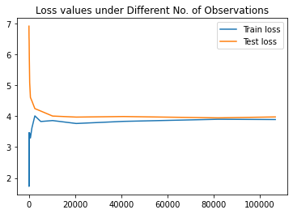

```python
results_dict_3c = {'n':[],
                'Train_loss': [],
                'Test_loss': []}

for k in range(15):
  n = 10*(2**k)
  n = min(len(X_train), n) # I noticed that only for k==14, n>nrow(len(X)train).

  # Filter data
  X_train_ = X_train[:n]
  y_train_ = y_train[:n]

  # run a logistic regression
  logreg = LogisticRegression()
  logreg.fit(X_train_, y_train_)

  # Store values
  y_pred = logreg.predict(X_train_)
  train_loss = metrics.log_loss(y_train_, y_pred)

  y_pred = logreg.predict(X_test)
  test_loss = metrics.log_loss(y_test, y_pred)

  results_dict_3c['n'].append(n)
  results_dict_3c['Train_loss'].append(train_loss)
  results_dict_3c['Test_loss'].append(test_loss)

# Plot results
plt.plot(results_dict_3c['n'], results_dict_3c['Train_loss'])
plt.plot(results_dict_3c['n'], results_dict_3c['Test_loss'])
plt.legend(['Train loss','Test loss'])
plt.title('Loss values under Different No. of Observations')
plt.show()
```

Do we see an improvement when increasing n ?

We see that at first, with a low number of observations, our model tends to overfit. It shows low loss values on the training set while relatively high values for the test set. As the number of observations increases, the two losses converge, with a steep fall in the test's set loss and then relatively flat changes with respect to `n`.

**3.(d) [9 pt] Combining models from similar data:**

- Find the maximal power $k$ such that the test error for $n = 10 \times 2^k$ is at least $0.02$ lower than the test error for the maximal $n$ (denoted $n_{max}$ you have used in **3.(c)**.
- Split the maximal training set you have used into $n_{max} / n$ random blocks of equal size.
- Run a logistic regression model on each block separately
- Finally, average the fitted models coefficients to get a combined model.
- Report the train and test accuracy for the combined model on the entire (unified) training and test set.
- How does it compare to the results from the **3.(c)** where fitting the model using the entire dataset? is the accuracy diminished/comparable/improved?
- At what circumstances would you recommend this approach of splitting the data to blocks and combining the models?

**Solution:**

```python
# 1. Finding k
# I have found that only k = 13 achieve smaller loss in at least 0.02 points, from
# the loss we get from using k=14.

# 2. Split the maximal training set you have used into  nmax/n  random blocks
batch_size_ = (10*(2**14)) / (10*(2**13))
# =2, meaning that we need to split our data into two batches

# In order to split my dataset, which is not iterable, I will split it's indices
# using the batch function from the previous part.
def batch(iterable, batch_size = 128):
  """
  Split an iterable object into batchas of size `batch_size`.
  Inputs:
  - `iterable`: an iterable object, list or np array. For pd DataFrame,
    this function can be used in order to return the indices in each
    mini batch.
  - `batch_size`: the size of each batch the function will return.
  Output:
  - `min_matches`: a list (of numbers/arrays/DataFrames), with each
    element in size `batch_size`.
  """
  # init
  min_matches = []
  idx = 0

  while idx + batch_size < len(iterable):
    # define and save a batch
    batch = iterable[idx:(idx + batch_size)]
    min_matches.append(batch)
    # update index
    idx += batch_size

  if idx + batch_size >= len(iterable):
    batch = iterable[idx:len(iterable)]
    min_matches.append(batch)

  return min_matches

indices = np.arange(X_train.shape[0])
np.random.shuffle(indices) # randomize
batch_size = int(len(indices)/2)

indices_batch = batch(indices, batch_size=batch_size)

# 3. Run a logistic regression on each of the batches
# First batch
X_train_ = X_train[indices_batch[0],] # keep only the relevant rows
y_train_ = y_train[indices_batch[0]] # keep only the relevant outcomes

logreg_1 = LogisticRegression()
logreg_1.fit(X_train_, y_train_)

# Second batch
X_train_ = X_train[indices_batch[1],] # keep only the relevant rows
y_train_ = y_train[indices_batch[1]] # keep only the relevant outcomes

logreg_2 = LogisticRegression()
logreg_2.fit(X_train_, y_train_)

# 4. Average the fitted models coefficients to get a combined model
avg_model = (logreg_1.coef_ + logreg_2.coef_)/2

# 5. Report Accuracies on the unified training data and on the test data
# Unified Training Set
y_pred = X_train.dot(avg_model.T)
y_pred[y_pred<0.5] = 0
y_pred[y_pred>=0.5] = 1

print('-'*80)
print(f'Accuracy Score on the training set is {np.round(metrics.accuracy_score(y_train, y_pred),3)}.')

# Test Set
y_pred = X_test.dot(avg_model.T)
y_pred[y_pred<0.5] = 0
y_pred[y_pred>=0.5] = 1

print('-'*80)
print(f'Accuracy Score on the test set is {np.round(metrics.accuracy_score(y_test, y_pred),3)}.')
print('-'*80)
```

```
--------------------------------------------------------------------------------
Accuracy Score on the training set is 0.688.
--------------------------------------------------------------------------------
Accuracy Score on the test set is 0.687.
--------------------------------------------------------------------------------
```

6.How does it compare to the results from the **3.(c)** where fitting the model using the entire dataset? is the accuracy diminished/comparable/improved?

Splitting our sample and averaging over the given weights yielded much lower accuracies in comparison with one-time regression. We had lower performance both on the unified training and test sets.

7.At what circumstances would you recommend this approach of splitting the data to blocks and combining the models?

I would guess that splitting our dataset and averaging the weights would be somewhat appropriate when encountering a small dataset. This method would probably be used alongside bootstrapping the observations. Another suitable case is when our training set is very heterogeneous.  
When we have only a small number of observations, we have this kind of heterogeneity. In such cases, we tend to have relatively noisy data, and large sample properties do not take place.

While we did not state it directly, what we have done here is called [model averaging](https://en.wikipedia.org/wiki/Bootstrap_aggregating), or just bagging.

**3.(e) [10 pt] Combining models from different datasets:**

- Pick $10$ different categories from the Amazon reviews dataset.
- For each dataset, read a batch of $100,000$ examples and split to train/test randoly with an `80%|20%` ratio as before.
- **Note:** You may pick large categories. **Do not** download the whole file as in **1.(d)**. Instead, use `readlines` to download only the first $100,000$.
- Run a logistic regression model on each category separately and report the train/test accuracies in a table.
- Finally, average the fitted models coefficients from all categories to get a `combined model`.
- Report the train and test accuracy for the `combined model` on the training and test set of each category separately.
- Did adding $\times10$ more examples help in improving the accuracy compared to fitting each category separately? why do you think this happened?

**Solution:**

```python
def download_from_AWS(catagory, batch = 100000):
  """
  Easy way to download content from AWS for a selected category.
  """
  def BytesToStr(b):
    lst = b.split(b'\t')
    return [elem.decode('UTF-8') for elem in lst]

  # init
  fileToStream = catagory[0]
  # Reading the file (may take time?)
  s3conn.Bucket('amazon-reviews-pds').download_file(fileToStream, 'tmp.gz')
  % ls /content/ -lah

  # read lines
  t = 0
  with gzip.open('/content/tmp.gz', 'rb') as f:
    lines = []
    for line in f:
      if t<=batch:
        lines.append(line)
        # print('got line', line)
        t +=1
      else:
        break

  # turn list into df
  df = pd.DataFrame(list(map(BytesToStr, lines)))
  df.columns = list(df.iloc[0])
  df = df.iloc[1:].reset_index(drop = True)

  return df
def batch_(iterable, batch_size = 128):
  """
  Split an iterable object into batchas of size `batch_size`.
  Inputs:
  - `iterable`: an iterable object, list or np array. For pd DataFrame,
    this function can be used in order to return the indices in each
    mini batch.
  - `batch_size`: the size of each batch the function will return.
  Output:
  - `min_matches`: a list (of numbers/arrays/DataFrames), with each
    element in size `batch_size`.
  """
  # init
  min_matches = []
  idx = 0

  while idx + batch_size < len(iterable):
    # define and save a batch
    batch = iterable[idx:(idx + batch_size)]
    min_matches.append(batch)
    # update index
    idx += batch_size

  if idx + batch_size >= len(iterable):
    batch = iterable[idx:len(iterable)]
    min_matches.append(batch)

  return min_matches

def wrapper(catagory, batch = 100000, test_size=0.20):
  """
  Load lines from AWS, process, split, run logistic regression and report resutls.
  """
  print("-*"*40)
  print(f"Category Name: {catagory[0]}")
  print("-*"*40)

  # Load Data
  df = download_from_AWS(catagory = catagory, batch = batch)

  # Processing

  ## text normalization and standardization with nltk
  df = function_2a(df)

  ## Add Sentiment values and scores using the pre-trained rnn
  processed_text = df['reviews_processed'].values
  # split our array into batches of size 10,000
  processed_text_batches = batch_(processed_text, batch_size = 10000)
  # get sentiment for each batch (and compute time)
  results = np.array([])
  for batch in processed_text_batches:
    results = np.append(results, get_sentiment(batch, mini_batch_size = 128, verbose=False))

  # Add both the sentiments' scores (sent_score) and the sentiments' values (sent_value)
  scores = []
  values = []

  for j in range(len(results)):
    result = results[j]
    scores.append(result.score)
    values.append(result.value)

  df['sent_score'] = scores
  df['sent_value'] = values

  ## Encoding/Setting binary variables
  df = function_2d(df)

  ## Fit and Transform
  mapper = DataFrameMapper([
      ('reviews_processed', TfidfVectorizer(max_features=100)),
      ('helpful_votes', None),
      ('total_votes', None),
      ('sent_score', None),
      ('sent_value', None)
  ], df_out=False)

  """
  Use the fit_transform method to transform the old dataframe into a new one
  that can be fed to the machine learning algorithm.
  """
  mapper_fit = mapper.fit(df)
  final_df = mapper.transform(df) # a numpy array

  # Split
  binstar = df['star_rating'].values
  X_train, X_test, y_train, y_test = train_test_split(
    final_df, binstar, test_size=test_size, random_state=42)

  # Regression
  logreg = LogisticRegression()
  logreg.fit(X_train, y_train)

  y_pred = logreg.predict(X_train)

  acc_train = metrics.accuracy_score(y_train, y_pred)

  y_pred = logreg.predict(X_test)

  acc_test = metrics.accuracy_score(y_test, y_pred)

  # return regression coefficients
  return [logreg.coef_, acc_train, acc_test, [X_train, X_test, y_train, y_test]]

logit_key1, acc_train_1, acc_test1, dfs1 = wrapper(keys_list[1], 10000)
logit_key2, acc_train_2, acc_test2, dfs2 = wrapper(keys_list[2], 10000)
logit_key3, acc_train_3, acc_test3, dfs3 = wrapper(keys_list[3], 10000)
logit_key4, acc_train_4, acc_test4, dfs4 = wrapper(keys_list[4], 10000)
logit_key5, acc_train_5, acc_test5, dfs5 = wrapper(keys_list[5], 10000)
logit_key6, acc_train_6, acc_test6, dfs6 = wrapper(keys_list[6], 10000)
logit_key7, acc_train_7, acc_test7, dfs7 = wrapper(keys_list[7], 10000)
logit_key8, acc_train_8, acc_test8, dfs8 = wrapper(keys_list[8], 10000)
logit_key9, acc_train_9, acc_test9, dfs9 = wrapper(keys_list[9], 10000)
logit_key10, acc_train_10, acc_test10, dfs10 = wrapper(keys_list[10], 10000)

res = dict({'Categories':[keys_list[1][0],
                          keys_list[2][0],
                          keys_list[3][0],
                          keys_list[4][0],
                          keys_list[5][0],
                          keys_list[6][0],
                          keys_list[7][0],
                          keys_list[8][0],
                          keys_list[9][0],
                          keys_list[10][0]],
      'Train Accuracy': [acc_train_1, acc_train_2, acc_train_3,
                         acc_train_4, acc_train_5, acc_train_6,
                         acc_train_7, acc_train_8, acc_train_9,
                         acc_train_10],
      'Test Accuracy': [acc_test1, acc_test2, acc_test3,
                         acc_test4, acc_test5, acc_test6,
                         acc_test7, acc_test8, acc_test9,
                         acc_test10]})
pd.DataFrame.from_dict(res).head(10)
```

```
-*-*-*-*-*-*-*-*-*-*-*-*-*-*-*-*-*-*-*-*-*-*-*-*-*-*-*-*-*-*-*-*-*-*-*-*-*-*-*-*
Category Name: tsv/amazon_reviews_us_Automotive_v1_00.tsv.gz
-*-*-*-*-*-*-*-*-*-*-*-*-*-*-*-*-*-*-*-*-*-*-*-*-*-*-*-*-*-*-*-*-*-*-*-*-*-*-*-*
total 556M
drwxr-xr-x 1 root root 4.0K Aug  7 01:40 ./
drwxr-xr-x 1 root root 4.0K Aug  6 17:43 ../
drwxr-xr-x 4 root root 4.0K Jul 16 13:19 .config/
drwxr-xr-x 1 root root 4.0K Jul 16 13:20 sample_data/
-rw-r--r-- 1 root root 556M Aug  7 01:40 tmp.gz
```

```
-*-*-*-*-*-*-*-*-*-*-*-*-*-*-*-*-*-*-*-*-*-*-*-*-*-*-*-*-*-*-*-*-*-*-*-*-*-*-*-*
Category Name: tsv/amazon_reviews_us_Baby_v1_00.tsv.gz
-*-*-*-*-*-*-*-*-*-*-*-*-*-*-*-*-*-*-*-*-*-*-*-*-*-*-*-*-*-*-*-*-*-*-*-*-*-*-*-*
total 341M
drwxr-xr-x 1 root root 4.0K Aug  7 01:40 ./
drwxr-xr-x 1 root root 4.0K Aug  6 17:43 ../
drwxr-xr-x 4 root root 4.0K Jul 16 13:19 .config/
drwxr-xr-x 1 root root 4.0K Jul 16 13:20 sample_data/
-rw-r--r-- 1 root root 341M Aug  7 01:40 tmp.gz
```

```
-*-*-*-*-*-*-*-*-*-*-*-*-*-*-*-*-*-*-*-*-*-*-*-*-*-*-*-*-*-*-*-*-*-*-*-*-*-*-*-*
Category Name: tsv/amazon_reviews_us_Beauty_v1_00.tsv.gz
-*-*-*-*-*-*-*-*-*-*-*-*-*-*-*-*-*-*-*-*-*-*-*-*-*-*-*-*-*-*-*-*-*-*-*-*-*-*-*-*
total 872M
drwxr-xr-x 1 root root 4.0K Aug  7 01:41 ./
drwxr-xr-x 1 root root 4.0K Aug  6 17:43 ../
drwxr-xr-x 4 root root 4.0K Jul 16 13:19 .config/
drwxr-xr-x 1 root root 4.0K Jul 16 13:20 sample_data/
-rw-r--r-- 1 root root 872M Aug  7 01:41 tmp.gz
-*-*-*-*-*-*-*-*-*-*-*-*-*-*-*-*-*-*-*-*-*-*-*-*-*-*-*-*-*-*-*-*-*-*-*-*-*-*-*-*
Category Name: tsv/amazon_reviews_us_Books_v1_00.tsv.gz
-*-*-*-*-*-*-*-*-*-*-*-*-*-*-*-*-*-*-*-*-*-*-*-*-*-*-*-*-*-*-*-*-*-*-*-*-*-*-*-*
total 2.6G
drwxr-xr-x 1 root root 4.0K Aug  7 01:42 ./
drwxr-xr-x 1 root root 4.0K Aug  6 17:43 ../
drwxr-xr-x 4 root root 4.0K Jul 16 13:19 .config/
drwxr-xr-x 1 root root 4.0K Jul 16 13:20 sample_data/
-rw-r--r-- 1 root root 2.6G Aug  7 01:42 tmp.gz
```

```
-*-*-*-*-*-*-*-*-*-*-*-*-*-*-*-*-*-*-*-*-*-*-*-*-*-*-*-*-*-*-*-*-*-*-*-*-*-*-*-*
Category Name: tsv/amazon_reviews_us_Books_v1_01.tsv.gz
-*-*-*-*-*-*-*-*-*-*-*-*-*-*-*-*-*-*-*-*-*-*-*-*-*-*-*-*-*-*-*-*-*-*-*-*-*-*-*-*
total 2.6G
drwxr-xr-x 1 root root 4.0K Aug  7 01:43 ./
drwxr-xr-x 1 root root 4.0K Aug  6 17:43 ../
drwxr-xr-x 4 root root 4.0K Jul 16 13:19 .config/
drwxr-xr-x 1 root root 4.0K Jul 16 13:20 sample_data/
-rw-r--r-- 1 root root 2.6G Aug  7 01:43 tmp.gz
```

```
-*-*-*-*-*-*-*-*-*-*-*-*-*-*-*-*-*-*-*-*-*-*-*-*-*-*-*-*-*-*-*-*-*-*-*-*-*-*-*-*
Category Name: tsv/amazon_reviews_us_Books_v1_02.tsv.gz
-*-*-*-*-*-*-*-*-*-*-*-*-*-*-*-*-*-*-*-*-*-*-*-*-*-*-*-*-*-*-*-*-*-*-*-*-*-*-*-*
total 1.3G
drwxr-xr-x 1 root root 4.0K Aug  7 01:44 ./
drwxr-xr-x 1 root root 4.0K Aug  6 17:43 ../
drwxr-xr-x 4 root root 4.0K Jul 16 13:19 .config/
drwxr-xr-x 1 root root 4.0K Jul 16 13:20 sample_data/
-rw-r--r-- 1 root root 1.3G Aug  7 01:44 tmp.gz
```

```
-*-*-*-*-*-*-*-*-*-*-*-*-*-*-*-*-*-*-*-*-*-*-*-*-*-*-*-*-*-*-*-*-*-*-*-*-*-*-*-*
Category Name: tsv/amazon_reviews_us_Camera_v1_00.tsv.gz
-*-*-*-*-*-*-*-*-*-*-*-*-*-*-*-*-*-*-*-*-*-*-*-*-*-*-*-*-*-*-*-*-*-*-*-*-*-*-*-*
total 423M
drwxr-xr-x 1 root root 4.0K Aug  7 01:46 ./
drwxr-xr-x 1 root root 4.0K Aug  6 17:43 ../
drwxr-xr-x 4 root root 4.0K Jul 16 13:19 .config/
drwxr-xr-x 1 root root 4.0K Jul 16 13:20 sample_data/
-rw-r--r-- 1 root root 423M Aug  7 01:46 tmp.gz
```

```
-*-*-*-*-*-*-*-*-*-*-*-*-*-*-*-*-*-*-*-*-*-*-*-*-*-*-*-*-*-*-*-*-*-*-*-*-*-*-*-*
Category Name: tsv/amazon_reviews_us_Digital_Ebook_Purchase_v1_00.tsv.gz
-*-*-*-*-*-*-*-*-*-*-*-*-*-*-*-*-*-*-*-*-*-*-*-*-*-*-*-*-*-*-*-*-*-*-*-*-*-*-*-*
total 2.6G
drwxr-xr-x 1 root root 4.0K Aug  7 01:47 ./
drwxr-xr-x 1 root root 4.0K Aug  6 17:43 ../
drwxr-xr-x 4 root root 4.0K Jul 16 13:19 .config/
drwxr-xr-x 1 root root 4.0K Jul 16 13:20 sample_data/
-rw-r--r-- 1 root root 2.6G Aug  7 01:47 tmp.gz
```

```
-*-*-*-*-*-*-*-*-*-*-*-*-*-*-*-*-*-*-*-*-*-*-*-*-*-*-*-*-*-*-*-*-*-*-*-*-*-*-*-*
Category Name: tsv/amazon_reviews_us_Digital_Ebook_Purchase_v1_01.tsv.gz
-*-*-*-*-*-*-*-*-*-*-*-*-*-*-*-*-*-*-*-*-*-*-*-*-*-*-*-*-*-*-*-*-*-*-*-*-*-*-*-*
total 1.3G
drwxr-xr-x 1 root root 4.0K Aug  7 01:47 ./
drwxr-xr-x 1 root root 4.0K Aug  6 17:43 ../
drwxr-xr-x 4 root root 4.0K Jul 16 13:19 .config/
drwxr-xr-x 1 root root 4.0K Jul 16 13:20 sample_data/
-rw-r--r-- 1 root root 1.3G Aug  7 01:47 tmp.gz
-*-*-*-*-*-*-*-*-*-*-*-*-*-*-*-*-*-*-*-*-*-*-*-*-*-*-*-*-*-*-*-*-*-*-*-*-*-*-*-*
Category Name: tsv/amazon_reviews_us_Digital_Music_Purchase_v1_00.tsv.gz
-*-*-*-*-*-*-*-*-*-*-*-*-*-*-*-*-*-*-*-*-*-*-*-*-*-*-*-*-*-*-*-*-*-*-*-*-*-*-*-*
total 242M
drwxr-xr-x 1 root root 4.0K Aug  7 01:48 ./
drwxr-xr-x 1 root root 4.0K Aug  6 17:43 ../
drwxr-xr-x 4 root root 4.0K Jul 16 13:19 .config/
drwxr-xr-x 1 root root 4.0K Jul 16 13:20 sample_data/
-rw-r--r-- 1 root root 242M Aug  7 01:48 tmp.gz
```

|  | Categories | Train Accuracy | Test Accuracy |
| --- | --- | --- | --- |
| 0 | tsv/amazon_reviews_us_Automotive_v1_00.tsv.gz | 0.921007 | 0.921842 |
| 1 | tsv/amazon_reviews_us_Baby_v1_00.tsv.gz | 0.924346 | 0.924796 |
| 2 | tsv/amazon_reviews_us_Beauty_v1_00.tsv.gz | 0.912967 | 0.898268 |
| 3 | tsv/amazon_reviews_us_Books_v1_00.tsv.gz | 0.951841 | 0.949306 |
| 4 | tsv/amazon_reviews_us_Books_v1_01.tsv.gz | 0.931548 | 0.922619 |
| 5 | tsv/amazon_reviews_us_Books_v1_02.tsv.gz | 0.912012 | 0.902981 |
| 6 | tsv/amazon_reviews_us_Camera_v1_00.tsv.gz | 0.922401 | 0.917297 |
| 7 | tsv/amazon_reviews_us_Digital_Ebook_Purchase_v... | 0.948105 | 0.939594 |
| 8 | tsv/amazon_reviews_us_Digital_Ebook_Purchase_v... | 0.946795 | 0.947078 |
| 9 | tsv/amazon_reviews_us_Digital_Music_Purchase_v... | 0.975143 | 0.973418 |

```python
# Average results
average_weights = \
  (logit_key1 + logit_key2 + logit_key3 + logit_key4 + logit_key5 + \
  logit_key6 + logit_key7 + logit_key8 + logit_key9 + logit_key10)/10

# Report the train and test accuracy for the combined model
# on the training and test set of each category separately.
def average_weights_pred(dfs, avg_model):
  # Unroll datasets
  X_train, X_test, y_train, y_test = dfs

  # Unified Training Set
  y_pred = X_train.dot(avg_model.T)
  y_pred[y_pred<0.5] = 0
  y_pred[y_pred>=0.5] = 1

  train_acc = np.round(metrics.accuracy_score(y_train, y_pred),3)

  # Test Set
  y_pred = X_test.dot(avg_model.T)
  y_pred[y_pred<0.5] = 0
  y_pred[y_pred>=0.5] = 1

  test_acc = np.round(metrics.accuracy_score(y_test, y_pred),3)

  return [train_acc, test_acc]

train_acc1, test_acc1 = average_weights_pred(dfs1, average_weights)
train_acc2, test_acc2 = average_weights_pred(dfs2, average_weights)
train_acc3, test_acc3 = average_weights_pred(dfs3, average_weights)
train_acc4, test_acc4 = average_weights_pred(dfs4, average_weights)
train_acc5, test_acc5 = average_weights_pred(dfs5, average_weights)
train_acc6, test_acc6 = average_weights_pred(dfs6, average_weights)
train_acc7, test_acc7 = average_weights_pred(dfs7, average_weights)
train_acc8, test_acc8 = average_weights_pred(dfs8, average_weights)
train_acc9, test_acc9 = average_weights_pred(dfs9, average_weights)
train_acc10, test_acc10 = average_weights_pred(dfs10, average_weights)

res = dict({'Categories':[keys_list[1][0],
                          keys_list[2][0],
                          keys_list[3][0],
                          keys_list[4][0],
                          keys_list[5][0],
                          keys_list[6][0],
                          keys_list[7][0],
                          keys_list[8][0],
                          keys_list[9][0],
                          keys_list[10][0]],
      'Train Accuracy': [train_acc1,
                         train_acc2,
                          train_acc3,
                          train_acc4,
                          train_acc5,
                          train_acc6,
                          train_acc7,
                          train_acc8,
                          train_acc9,
                          train_acc10],
      'Test Accuracy': [test_acc1,
                        test_acc2,
                        test_acc3,
                        test_acc4,
                        test_acc5,
                        test_acc6,
                        test_acc7,
                        test_acc8,
                        test_acc9,
                        test_acc10]})
pd.DataFrame.from_dict(res).head(10)
```

|  | Categories | Train Accuracy | Test Accuracy |
| --- | --- | --- | --- |
| 0 | tsv/amazon_reviews_us_Automotive_v1_00.tsv.gz | 0.857 | 0.862 |
| 1 | tsv/amazon_reviews_us_Baby_v1_00.tsv.gz | 0.866 | 0.873 |
| 2 | tsv/amazon_reviews_us_Beauty_v1_00.tsv.gz | 0.832 | 0.825 |
| 3 | tsv/amazon_reviews_us_Books_v1_00.tsv.gz | 0.864 | 0.879 |
| 4 | tsv/amazon_reviews_us_Books_v1_01.tsv.gz | 0.798 | 0.792 |
| 5 | tsv/amazon_reviews_us_Books_v1_02.tsv.gz | 0.689 | 0.678 |
| 6 | tsv/amazon_reviews_us_Camera_v1_00.tsv.gz | 0.852 | 0.851 |
| 7 | tsv/amazon_reviews_us_Digital_Ebook_Purchase_v... | 0.847 | 0.843 |
| 8 | tsv/amazon_reviews_us_Digital_Ebook_Purchase_v... | 0.807 | 0.811 |
| 9 | tsv/amazon_reviews_us_Digital_Music_Purchase_v... | 0.918 | 0.919 |

Did adding ×10 more examples help in improving the accuracy compared to fitting each category separately? why do you think this happened?

Similar to the previous part, using averaged weights did not improve my prediction; on the contrary.  
I guess it makes sense because when one fits one model within each category, it is supposed to predict better on a test set that is made of a similar test set. In other words, when we estimated different models for different categories, we tested our models on relatively similar test sets.

It would be interesting, though, to test the average weights **on a new category** and test whether it be generalized better than any of the separated ones.

### **Part 4: Fitting steaming data using Stochastic Gradient Descent**

While we were able to create a predictive model, we used a small subset of the entire data. Using Colab's available resources, it is impossible to run the model on the entire data. To get around loading the entire data in memory at once, we can use `stochastic gradient descent` to train the model a `(mini) batch` at a time.

**4.(a) [3 pt]** Create an `SGDClassifier` object with the logisitc regression loss. You may choose parameters for learning rate (the step-size at each iteration), penalties etc.  
See [here](https://scikit-learn.org/stable/modules/generated/sklearn.linear_model.SGDClassifier.html#sklearn.linear_model.SGDClassifier.partial_fit) for more details. If you don't understand a parameter, just keep the default value.

**Solution:**

```python
# At first my classifier did not converge, so I added params to regularize it
GSDlogred = SGDClassifier(loss='log', warm_start = True,
                          alpha=.01, penalty='l2', max_iter=90, verbose=0, tol=0.001)
```

**4.(b) [6 pt]**

- For the same `train_set` fitted in **3.(a), 3.(b)**, apply the SGD classifier for $50$ epochs (passes over the entire data) using the `partial_fit` method of the object `GSDlogred` you have created in **4.(a)**.
- Plot the loss of the classifier as a function of the number of epochs. Does it seem to converge?
- Compute the test error of the final output classifier. How does it compare to the error in **3.(b)** ?

**Solution:**

NOTE: I tweaked GSDlogred's params so that the losses would seem a bit better and would resemble something that may converge after more iterations.

I also tried to use mini-batches. It did not help, so I neglected this approach and did not include the code in this notebook.

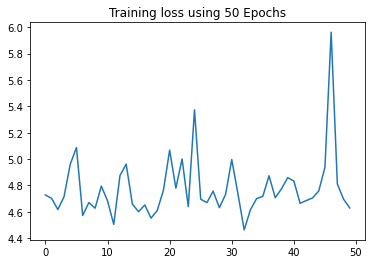

```python
# Apply SGD for 50 epochs
n_iter = 50
losses = []
indices = np.arange(X_train.shape[0])

for n in range(n_iter):
    # Randomize (partial_fit does not effected by the shuffle option)
    # np.random.shuffle(indices) # randomization made it hurder to converge
    X_train_ = X_train[indices,]
    y_train_ = y_train[indices]

    GSDlogred.partial_fit(X_train_, y_train_, classes=np.unique(y_train_))

    y_pred = GSDlogred.predict(X_train_)
    train_loss = metrics.log_loss(y_train_, y_pred)
    losses.append(train_loss)
plt.plot(losses)
plt.title('Training loss using 50 Epochs')
plt.show()
```

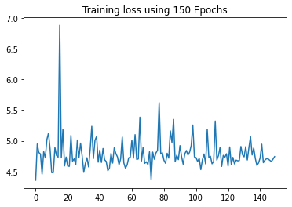

```python
# Apply SGD for 150 epochs (just for sport)
n_iter = 150
losses = []
indices = np.arange(X_train.shape[0])

GSDlogred150 = SGDClassifier(loss='log',
                          alpha=.01, penalty='l2', max_iter=90, verbose=0, tol=0.001)

for n in range(n_iter):
    # Randomize (partial_fit does not effected by the shuffle option)
    # np.random.shuffle(indices) # randomization made it hurder to converge
    X_train_ = X_train[indices,]
    y_train_ = y_train[indices]

    GSDlogred150.partial_fit(X_train_, y_train_, classes=np.unique(y_train_))

    y_pred = GSDlogred150.predict(X_train_)
    train_loss = metrics.log_loss(y_train_, y_pred)
    losses.append(train_loss)
plt.plot(losses)
plt.title('Training loss using 150 Epochs')
plt.show()
```

```python
# Compute the test error with GSDlogred (of 50 iterations)
y_pred = GSDlogred.predict(X_test)
test_loss = metrics.log_loss(y_test, y_pred)
print(f'Using GSDlogred, loss value on the test set is {test_loss}.')
```

```
Using GSDlogred, loss value on the test set is 4.8284549848516045.
```

**Q**: Compute the test error of the final output classifier. How does it compare to the error in 3.(b) ?

**4.(c) [6 pt]** Pick one of the six *largest* categories in the AWS dataset.

Modify and use the `obj` defined in the cell below, to `stream` (readlines) and loop through the gzip file of this category `100000` bytes at a time, with at least `100` batches (all done inside a `with` connection to the gzip file):

- Make sure each `batch` is parsed appropriately (as have been done already)
- Create a `pandas` dataframe for each `batch` (within each loop) and print the number of rows (data points) in the `batch`
- Update the model parameters by executing the `GSDlogred.partial_fit` method on each processed batch (apply all the preprocessing steps we did in **Part 2** to get a processed numpy array, and the splitting to train and test sets before training the model as in **Part 3**).  
  For each batch report the test accuracy for this batch, and also the *average* test accuracy over all batches so far. Do you see an improvement as you use more and more batches?

**Note:** Make sure that your fitting algorithm uses each data point in the batch only once, as is appropriate for the streaming model. Also make sure that when updating the parameters for each batch, the classifier is initialized with the parameters fitted already using previous batches. Modify the `GSDlogred` object if needed, before looping over batches, to accomodate these changes and other changes needed to deal with the data stream.

**Solution:**

```python
# Pick one of the six largest categories
file_categories_df.sort_values(['estSizeGB']).\
  tail(6)
# Note: I'll go with Wireless.
```

[output not shown]

```python
maxCount = 100
batch_size = 100000 #bytes

# init values for the overall accuracy
N = 0
TRUEs = 0

# defining obj
bucket_name = 'amazon-reviews-pds'
key = 'tsv/amazon_reviews_us_Wireless_v1_00.tsv.gz'
obj = s3conn.Object(bucket_name, key)

counter = 0
with gzip.GzipFile(fileobj=obj.get()["Body"]) as gzipfile:
    while counter < maxCount:
        # load a batch of reviews in a list format
        batch = [i.decode().replace('""','"').strip().split('\t') for i in gzipfile.readlines(batch_size)]
        batch_df = pd.DataFrame(batch)

        # keep names and remove first row if first
        if counter == 0:
          names = list(batch_df.iloc[0])
          batch_df = batch_df.iloc[1:]
          batch_df.reset_index(drop = True, inplace = True)

        # rename
        batch_df.columns = names

        # Processing

        ## text normalization and standardization with nltk
        batch_df = function_2a(batch_df)

        ## Add Sentiment values and scores using the pre-trained rnn
        processed_text = batch_df['reviews_processed'].values
        # split our array into batches of size 10,000
        processed_text_batches = batch_(processed_text, batch_size = 10000)
        # get sentiment for each batch (and compute time)
        results = np.array([])
        for batch in processed_text_batches:
          results = np.append(results, get_sentiment(batch, mini_batch_size = 128, verbose=False))

        # Add both the sentiments' scores (sent_score) and the sentiments' values (sent_value)
        scores = []
        values = []

        for j in range(len(results)):
          result = results[j]
          scores.append(result.score)
          values.append(result.value)

        batch_df['sent_score'] = scores
        batch_df['sent_value'] = values

        ## Encoding/Setting binary variables
        batch_df = function_2d(batch_df)

        ## Fit and Transform
        mapper = DataFrameMapper([
            ('reviews_processed', TfidfVectorizer(max_features=100)),
            ('helpful_votes', None),
            ('total_votes', None),
            ('sent_score', None),
            ('sent_value', None)
        ], df_out=False)

        """
        Use the fit_transform method to transform the old dataframe into a new one
        that can be fed to the machine learning algorithm.
        """
        mapper_fit = mapper.fit(batch_df)
        final_df = mapper.transform(batch_df) # a numpy array

        # Split
        binstar = batch_df['star_rating'].values
        X_train, X_test, y_train, y_test = train_test_split(
          final_df, binstar, test_size=0.2, random_state=42)

        # Perform a step using our batch
        GSDlogred=GSDlogred.partial_fit(X_train,y_train, [0,1])

        # Predict on the test set
        y_pred = GSDlogred.predict(X_test)
        test_acc = metrics.accuracy_score(y_test, y_pred)

        # Calculate Accuraty so Far
        N += X_test.shape[0]
        TRUEs += np.sum((y_pred == y_test).astype('int32'))

        rolling_acc = TRUEs/N

        print('-'*80)
        print(f'Finished batch {counter}..')
        print(f'Test Acc {test_acc}.')
        print(f'Overall Test Acc {rolling_acc}.')
        print('-'*80)

        # continue to next batch
        counter +=1
```

```
--------------------------------------------------------------------------------
Finished batch 0..
Test Acc 0.8048780487804879.
Overall Test Acc 0.8048780487804879.
--------------------------------------------------------------------------------
--------------------------------------------------------------------------------
Finished batch 1..
Test Acc 0.7441860465116279.
Overall Test Acc 0.7738095238095238.
--------------------------------------------------------------------------------
--------------------------------------------------------------------------------
Finished batch 2..
Test Acc 0.8297872340425532.
Overall Test Acc 0.7938931297709924.
--------------------------------------------------------------------------------
--------------------------------------------------------------------------------
Finished batch 3..
Test Acc 0.7608695652173914.
Overall Test Acc 0.7853107344632768.
--------------------------------------------------------------------------------
--------------------------------------------------------------------------------
Finished batch 4..
Test Acc 0.8888888888888888.
Overall Test Acc 0.8063063063063063.
--------------------------------------------------------------------------------
--------------------------------------------------------------------------------
Finished batch 5..
Test Acc 0.8372093023255814.
Overall Test Acc 0.8113207547169812.
--------------------------------------------------------------------------------
--------------------------------------------------------------------------------
Finished batch 6..
Test Acc 0.7450980392156863.
Overall Test Acc 0.8006329113924051.
--------------------------------------------------------------------------------
--------------------------------------------------------------------------------
Finished batch 7..
Test Acc 0.8125.
Overall Test Acc 0.8021978021978022.
--------------------------------------------------------------------------------
```

[output cut: 445 more lines]

```
--------------------------------------------------------------------------------
Finished batch 97..
Test Acc 0.7272727272727273.
Overall Test Acc 0.8149059982094897.
--------------------------------------------------------------------------------
--------------------------------------------------------------------------------
Finished batch 98..
Test Acc 0.7692307692307693.
Overall Test Acc 0.8145107610383847.
--------------------------------------------------------------------------------
--------------------------------------------------------------------------------
Finished batch 99..
Test Acc 0.7906976744186046.
Overall Test Acc 0.8142857142857143.
--------------------------------------------------------------------------------
```

**Q** : Do you see an improvement as you use more and more batches?

Yes. We started with accuracy of about 0.8, and as the number of epochs has increased, our accuracy has improved. We ended up with about 0.814.

**4.(d) [6 pt] Open Question** How can you improve the classifier? Suggest and implement a way to train a classifier such that the test error on the category you picked in question **1.(d)** will improve compared to all previous results for this test set.

You can be creative: use additional data, fit additional models (e.g. nonlinear), change the training algorithm, etc.

Report the running time and the test accuracy of your algorithm

**Solution:**

The SGDClassifier uses logistic regression given that `loss = "log"`. In other words, it uses only one layer of non-linearity to classify our review scores into one of the binary outcomes.  
In this part, I take advantage of `skorch` library, a `scikit-learn` compatible neural network library that wraps `PyTorch`.

For our context, the main advantage of skorch, is that it allows us to use pytorch architecture along with the `partial_fit()` command from scikit-learn, which fits streaming data.

I use SGD optimizer as well and add a `relu` activation function between layers.  
Of course, the deeper the network is, the more data we need in order to optimize it, so I increase the number of batches from 100 to 500.

- One could argue that with high-level features such as we have (after we converted words into scores), it is better to use trees, for example. Nevertheless, in most cases, trees are not fit for incremental learning (that is what we do here, actually). Those that are fit (`CART`, `ID3` and `C4`) are not compatible with the basic scikit (but are available with `scikit-multiflow`). And because the skorch syntax is much closer to the sckit syntax, I go with it.

```python
!pip install skorch
```

```python
import torch
from skorch import NeuralNet

class SimpleFeedforward(nn.Module):
    def __init__(self, dropout=0.5):
      super().__init__()
      self.relu = torch.nn.ReLU()
      self.linear1 = torch.nn.Linear(104,68)
      self.linear2 = torch.nn.Linear(68, 48)
      self.linear3 = torch.nn.Linear(48, 16)
      self.linear4 = torch.nn.Linear(16, 1)
      self.dropout = torch.nn.Dropout(dropout)
      self.sigmoid = torch.nn.Sigmoid()

    def forward(self, x):
      x = self.linear1(x)
      x = self.relu(x)
      x = self.dropout(x)
      x = self.linear2(x)
      x = self.relu(x)
      x = self.dropout(x)
      x = self.linear3(x)
      x = self.relu(x)
      x = self.dropout(x)
      x = self.linear4(x)
      x = self.sigmoid(x)
      return x


# learning rate scheduler
lr_scheduler = LRScheduler(
  policy = "StepLR",
  step_size = 1000, # update lr between epochs
  gamma = 0.95
)


net = NeuralNet(
    SimpleFeedforward,
    criterion=nn.BCELoss,
    max_epochs=10, # epochs over the same batch
    callbacks = [lr_scheduler],
    lr=0.025
)

#########################
# Strem Data
#########################


maxCount = 500
batch_size = 100000 #bytes

# init values for the overall accuracy
N = 0
TRUEs = 0

# defining obj
bucket_name = 'amazon-reviews-pds'
key = 'tsv/amazon_reviews_us_Wireless_v1_00.tsv.gz'
obj = s3conn.Object(bucket_name, key)

tic = time.time() # take time
acc_hist = []

counter = 0
with gzip.GzipFile(fileobj=obj.get()["Body"]) as gzipfile:
    while counter < maxCount:
        # load a batch of reviews in a list format
        batch = [i.decode().replace('""','"').strip().split('\t') for i in gzipfile.readlines(batch_size)]
        batch_df = pd.DataFrame(batch)

        # keep names and remove first row if first
        if counter == 0:
          names = list(batch_df.iloc[0])
          batch_df = batch_df.iloc[1:]
          batch_df.reset_index(drop = True, inplace = True)

        # rename
        batch_df.columns = names

        # Processing

        ## text normalization and standardization with nltk
        batch_df = function_2a(batch_df)

        ## Add Sentiment values and scores using the pre-trained rnn
        processed_text = batch_df['reviews_processed'].values
        # split our array into batches of size 10,000
        processed_text_batches = batch_(processed_text, batch_size = 10000)
        # get sentiment for each batch (and compute time)
        results = np.array([])
        for batch in processed_text_batches:
          results = np.append(results, get_sentiment(batch, mini_batch_size = 128, verbose=False))

        # Add both the sentiments' scores (sent_score) and the sentiments' values (sent_value)
        scores = []
        values = []

        for j in range(len(results)):
          result = results[j]
          scores.append(result.score)
          values.append(result.value)

        batch_df['sent_score'] = scores
        batch_df['sent_value'] = values

        ## Encoding/Setting binary variables
        batch_df = function_2d(batch_df)

        ## Fit and Transform
        mapper = DataFrameMapper([
            ('reviews_processed', TfidfVectorizer(max_features=100)),
            ('helpful_votes', None),
            ('total_votes', None),
            ('sent_score', None),
            ('sent_value', None)
        ], df_out=False)

        """
        Use the fit_transform method to transform the old dataframe into a new one
        that can be fed to the machine learning algorithm.
        """
        mapper_fit = mapper.fit(batch_df)
        final_df = mapper.transform(batch_df) # a numpy array

        # Split
        binstar = batch_df['star_rating'].values
        X_train, X_test, y_train, y_test = train_test_split(
          final_df, binstar, test_size=0.2, random_state=42)

        y_train = y_train.astype('float32').reshape(len(y_train),1)
        y_test  = y_test.astype('float32').reshape(len(y_test),1)

        X_train = X_train.astype('float32')
        X_test = X_test.astype('float32')

        # Perform a step using our batch
        net = net.partial_fit(X_train, y_train)
        # clf=clf.partial_fit(X_train,y_train, [0,1])

        # Predict on the test set
        # y_pred = clf.predict(X_test)
        y_pred = net.predict(X_test)

        test_acc = metrics.accuracy_score(y_test, np.round(y_pred))

        # Calculate Accuraty so Far
        N += X_test.shape[0]
        TRUEs += np.sum((np.round(y_pred) == y_test).astype('int32'))

        rolling_acc = TRUEs/(N+0.00000001)

        acc_hist.append(rolling_acc)

        print('-'*80)
        print(f'Finished batch {counter}..')
        print(f'Test Acc {test_acc}.')
        print(f'Overall Test Acc {rolling_acc}.')
        print('-'*80)

        # continue to next batch
        counter +=1

toc = time.time()
```

[output not shown]

[output cut: 4946 more lines]

```
   4991        0.3522        0.3261  0.0166  0.0103
   4992        0.3065        0.3267  0.0166  0.0160
   4993        0.3402        0.3282  0.0166  0.0171
   4994        0.3558        0.3293  0.0166  0.0151
   4995        0.3598        0.3304  0.0166  0.0163
   4996        0.3581        0.3313  0.0166  0.0158
   4997        0.3107        0.3317  0.0166  0.0186
   4998        0.3670        0.3325  0.0166  0.0166
   4999        0.3633        0.3326  0.0166  0.0158
   5000        0.4111        0.3321  0.0166  0.0231
--------------------------------------------------------------------------------
Finished batch 499..
Test Acc 0.9.
Overall Test Acc 0.8470205753982154.
--------------------------------------------------------------------------------
```

```
--------------------------------------------------------------------------------
It took 958.259 seconds to train the model.
--------------------------------------------------------------------------------
```

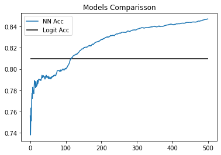

```python
print('-'*80)
print(f'It took {np.round(toc-tic,3)} seconds to train the model.')
print('-'*80)
plt.plot(acc_hist)
plt.hlines(0.8096703296703297,0,500)
plt.legend(['NN Acc','Logit Acc'])
plt.title("Models Comparisson")
plt.show()
```

As the above plot shows, I achieved better performance using another model, together with additional data. Nevertheless, it took much more time in order to train it.  
I chose 500 batches arbitrarily. The accuracy plot shows that adding more batches would probably improve our classifier.